# Future constructions in English and Norwegian

Olaf Mikkelsen & Stefan Hartmann

24 February, 2024

This file contains the scripts used for a contrastive analysis of English and Norwegian future constructions.

# Preliminaries

Load packages

```r
library(tidyverse)
library(readxl)
library(party)
library(lattice)
library(Hmisc)
library(pdp)
library(collostructions) # available at sfla.ch
library(patchwork)
library(ggparty)
library(Boruta)
library(svglite)
```

## Queries

The English data were queried via [CWB](https://cwb.sourceforge.io/). SpokenBNC2014 was transformed to CWB format using [this](https://github.com/hartmast/SpokenBNC2014_to_CWB) script. OANC was transformed to CWB using [this](https://github.com/hartmast/OANC_to_CWB) script. Uncollapse the following code box to see the queries.

```r
# Spoken BNC 2014
cqp -e
SPOKENBNC2014
[word="will|shall|going|wo|'?ll|gon"][word="to|n't|na"]?
cat Last > "will_shall_going_to_SPOKENBNC2014.txt"

# in addition, for taking priming effects into account:
cqp -e
SPOKENBNC2014;
set context 150 words;
show +u_who;
set ld "üüü";
set rd "üüü";
[word="will|shall|going|wo|'?ll|gon"][word="to|n't|na"]?;
cat Last > will_shall_going_to_SPOKENBNC2014_more_context.txt

In the text file, replace üüü by \t.

# OANC
cqp -e
OANCSPOKEN
set context s
show +lemma +pos
set PrintStructures "text_id, text_genre, text_file, turn_id, turn_age, turn_sex"
A = [word="will|shall|going|wo|ll|gon|gonna"][word="to|n't|na"]?
cat A > "oanc_spoken.txt"

# additional query for 'll files because the apostrophe
# was missing in the original query
cqp -e
OANCSPOKEN
set context s
show +lemma +pos
set PrintStructures "text_id, text_genre, text_file, turn_id, turn_age, turn_sex"
A = [word="'ll"]
cat A > "oanc_ll.txt"
```

# Data wrangling

## Read data

```r
# read data: Norwegian
nor_bb <- read_xlsx("data/Norwegian/nota_bb_vil_skal_komer_til_a.xlsx", sheet = "bigbrother")
nor_nota <- read_xlsx("data/Norwegian/nota_bb_vil_skal_komer_til_a.xlsx", sheet = "nota")
nor <- rbind(nor_nota, nor_bb)

# clean column names
colnames(nor) <- gsub(" ", "_", colnames(nor))

# read data: English
oanc <- read_csv("data/English/OANC/oanc_spoken_going_to_shall_will_5000.csv")
bnc  <- read_xlsx("data/English/SpokenBNC2014/SPOKENBNC2014_spoken_will_shall_going_to_sample_5000-final-priming.xlsx")
```

## Add annotation columns

Protasis/apodosis annotation columns are added automatically.

```r
# add protasis/apodosis annotation to BNC
bnc$if_clause2 <- ifelse(bnc$if_clause=="if" & bnc$subordinate=="sub", "protasis", NA)
bnc$if_clause2 <- ifelse(bnc$if_clause=="if" & bnc$subordinate=="main", "apodosis", bnc$if_clause2)
bnc$if_clause2 <- ifelse(bnc$if_clause!="if", "no", bnc$if_clause2)

# add protasis/apodosis annotation to OANC
oanc$if_clause2 <- ifelse(oanc$if_clause=="if" & oanc$subordinate=="sub", "protasis", NA)
oanc$if_clause2 <- ifelse(oanc$if_clause=="if" & oanc$subordinate=="main", "apodosis", oanc$if_clause2)
oanc$if_clause2 <- ifelse(oanc$if_clause!="if", "no", oanc$if_clause2)

# add protasis/apodosis annotation to NOR
nor$if_clause2 <- ifelse(nor$`If-clause`=="if" & nor$Clause_type=="sub", "protasis", "NA")
nor$if_clause2 <- ifelse(nor$`If-clause`=="if" & nor$Clause_type=="main", "apodosis", nor$if_clause2)
nor$if_clause2 <- ifelse(nor$`If-clause`!="if", "no", nor$if_clause2)
```

Also, we add columns with the outcome variable to the English data, with an additional column with a binary encoding (will / going to)

```r
# OANC ---------

# binary:
oanc$cxn <- ifelse(oanc$Key %in% c("gonna", "going"), "going_to", "will")

# more fine-grained:
oanc$cxn1 <- case_when(oanc$Key == "will" ~ "will",
                       oanc$Key == "'ll" ~ "'ll",
          oanc$Key == "shall" ~ "shall",
          oanc$Key == "wo" ~ "won't",
          oanc$Key == "going" ~ "going to",
          oanc$Key == "gonna" ~ "gonna")
oanc$cxn1 <- factor(oanc$cxn1, levels = c("will", "'ll", "shall", "won't", "going to", "gonna"))

# BNC ---------

# binary
bnc$cxn <- ifelse(bnc$Key %in% c("'ll", "will", "wo"), "will", "going to")

bnc$cxn1 <- case_when(bnc$Key == "gon" ~ "gonna",
          bnc$Key == "'ll" ~ "'ll",
          bnc$Key == "going" ~ "going to",
          bnc$Key == "will" ~ "will",
          bnc$Key == "wo" ~ "won't",
          bnc$Key == "shall" ~ "shall")

bnc$cxn1 <- factor(bnc$cxn1, levels = c("will", "'ll", "shall", "won't", "going to", "gonna"))
```

Omit false hits:

```r
bnc  <- bnc %>% filter(keep == "y")
oanc <- oanc %>% filter(keep=="y")
```

# Summary statistics

Number of hits per corpus:

```r
left_join(setNames(as.data.frame(table(bnc$cxn1)), c("Cxn", "BNC")),
          setNames(as.data.frame(table(oanc$cxn1)), c("Cxn", "OANC")))
```

| Cxn | BNC | OANC |
| --- | --- | --- |
| will | 518 | 865 |
| 'll | 1900 | 1402 |
| shall | 113 | 20 |
| won't | 233 | 210 |
| going to | 391 | 1626 |
| gonna | 1051 | 441 |

# CART Tree & Random forest - Norwegian

Fitting a conditional inference tree and a random forest to the Norwegian data:

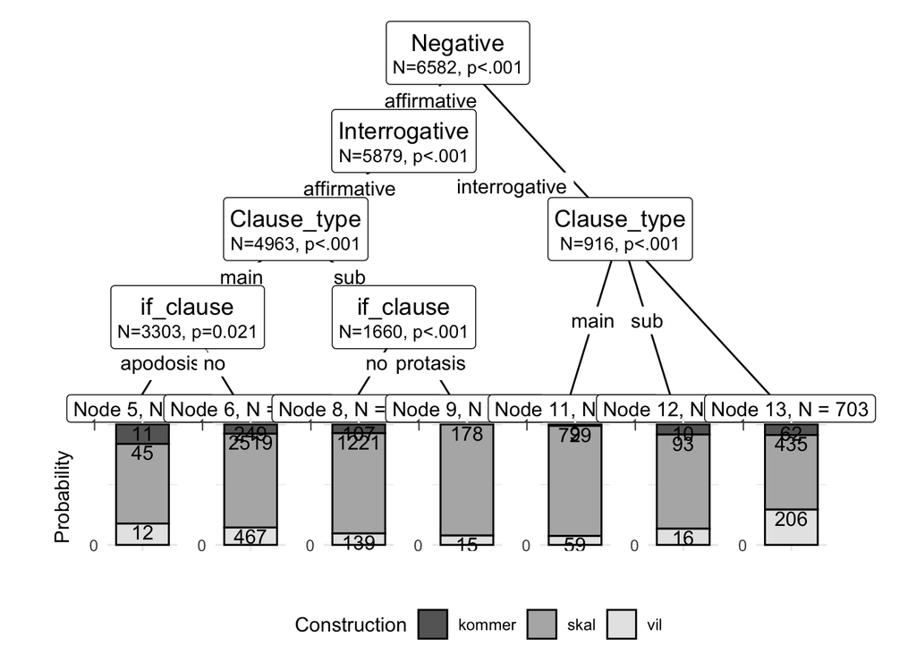

```r
# Norwegian: ---------------

# relevant variables as factors
nor$Cx <- factor(nor$Cx)
nor$Negative <- factor(nor$Negative)
nor$Interrogative <- factor(nor$Interrogative)
nor$if_clause2 <- factor(nor$if_clause2)
nor$Clause_type <- factor(nor$Clause_type)

# reduce number of levels for Lexeme
nor$Lexeme <- factor(nor$Lexeme)
nor$lexeme <- fct_lump_min(nor$Lexeme, min = 50, other_level = "other")


# more descriptive name
nor$Construction <- nor$Cx

# shorter cx labels (obsolete now that we're using ggparty)
nor$cxn <- case_when(nor$Cx == "kommer" ~ "k",
          nor$Cx == "skal" ~ "s",
          nor$Cx == "vil" ~ "v")
nor$cxn <- factor(nor$cxn)

# shorter if clause label
nor$if_clause <- nor$if_clause2

# CART tree
set.seed(19851003)
tr_nor <- ctree(Construction ~ Negative+Interrogative+if_clause+Clause_type,
                data = nor)

# plot - adapted from https://ladal.edu.au/tree.html

# extract p-values
pvals <- unlist(nodeapply(tr_nor, ids = nodeids(tr_nor), function(n) info_node(n)$p.value))
pvals <- pvals[pvals <.05]

( tr_nor_plot <- ggparty(tr_nor) +
  geom_edge() +
  geom_edge_label() +
  geom_node_label(line_list = list(aes(label = splitvar),
                                   aes(label = paste0("N=", nodesize, ", p",
                                                      ifelse(pvals < .001, "<.001", paste0("=", round(pvals, 3)))),
                                       size = 10)),
                  line_gpar = list(list(size = 13),
                                   list(size = 10)),
                  ids = "inner") +
  geom_node_label(aes(label = paste0("Node ", id, ", N = ", nodesize)),
    ids = "terminal", nudge_y = -0.0, nudge_x = 0.01) +
  geom_node_plot(gglist = list(
    geom_bar(aes(x = "", fill = Construction),
             position = position_fill(), color = "black"),
    theme_minimal(),
    scale_fill_grey(start = .4, end = .9),
    scale_y_continuous(breaks = c(0, 1)),
    xlab(""),
    ylab("Probability"),
    geom_text(aes(x = "", group = Construction,
                  label = after_stat(count)),
              stat = "count", position = position_fill(), vjust = 1.1)),
    shared_axis_labels = TRUE) )
```

```r
# export as pdf (ggsave not working for ggparty objects apparently)

# png("figures/tree_NO.png", width = 10, height = 6, un = "in", res = 300)
# plot(tr_nor)
# dev.off()
```

```r
# random forest
set.seed(19851003)
for_nor <- party::cforest(Cx ~ Negative+Interrogative+if_clause+Clause_type,
                data = nor,
                controls = cforest_unbiased(mtry = 2, ntree = 2000))
vi <- party::varimp(for_nor, conditional = TRUE)
```

Plot the variable importance:

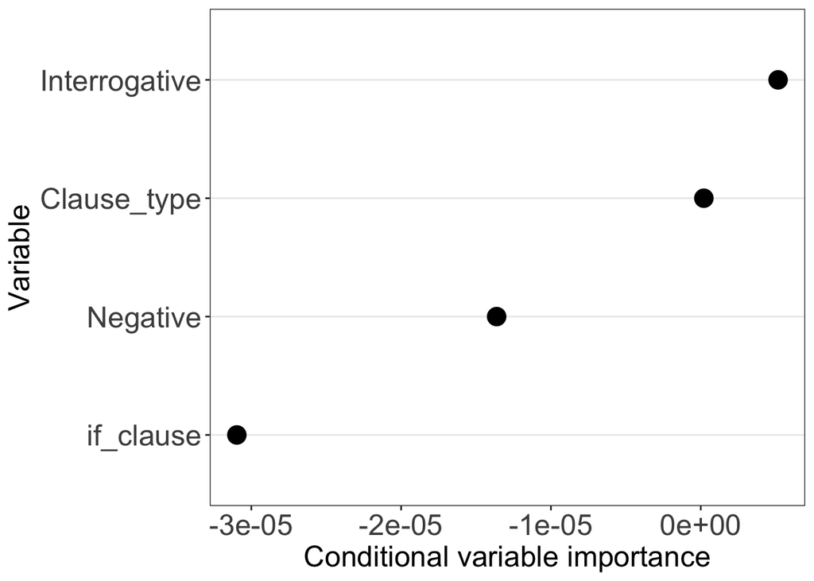

```r
(vi_plot_nor <- as.data.frame(vi) %>% rownames_to_column() %>% ggplot(aes(y = fct_reorder(rowname, vi), x = vi)) +
  geom_point(size = 5) + xlim(min(vi), max(vi)) +
  theme_bw() +
  theme(panel.grid.major.x = element_blank()) +
  theme(panel.grid.minor = element_blank()) + xlab("Conditional variable importance") + ylab("Variable") +
  theme(axis.text = element_text(size = 18)) +
  theme(axis.title = element_text(size = 18)) +
  theme(strip.text = element_text(size = 18)) +
  theme(legend.text = element_text(size = 18)) +
  theme(legend.title = element_text(size = 18, face = "bold")) +
  theme(text = element_text(size = 18)))
```

## Check model fit

Model accuracy

```r
# fitted values for out of bag sample
pred.nor <- predict(for_nor, OOB = T)
```

```r
# proportion of correct predictions
sum(as.numeric(sapply(1:length(pred.nor), function(i) pred.nor[i] == nor$Cx[i]))) / length(pred.nor)
```

```
## [1] 0.793072
```

## CART Tree and Random Forest - British and American English

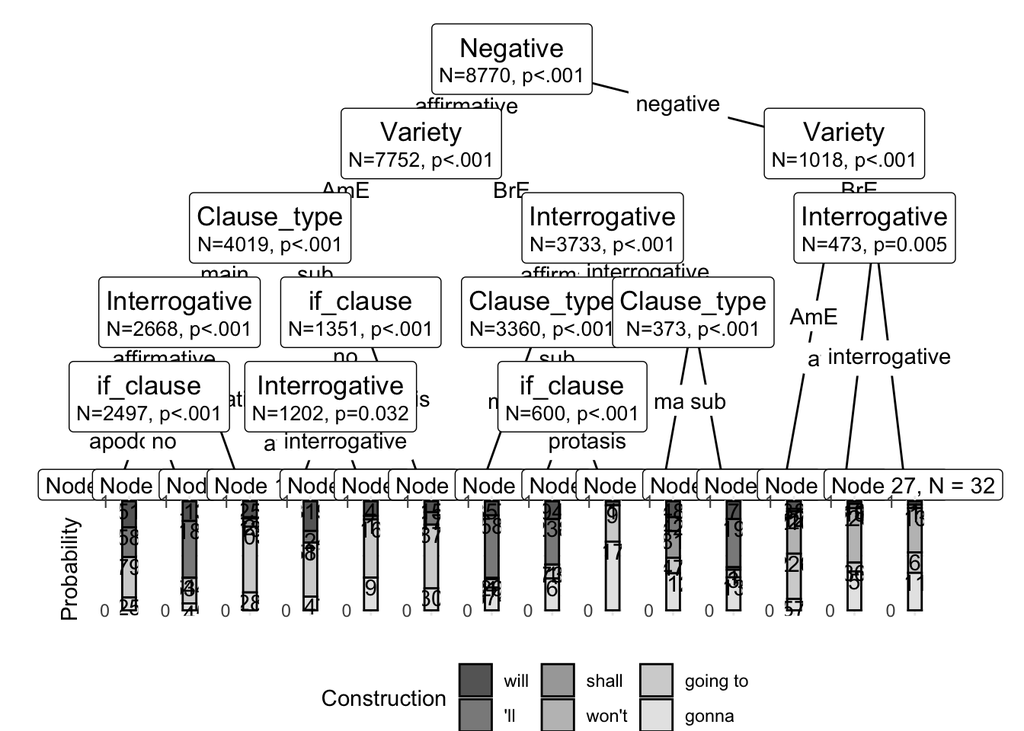

```r
# combine OANC and BNC2014 data

colnames(oanc)[which(colnames(oanc)=="gramm_person")] <- "Gramm_person"
colnames(oanc)[which(colnames(oanc)=="animacy")] <- "Animacy"
colnames(oanc)[which(colnames(oanc)=="question")] <- "Interrogative"
colnames(bnc)[which(colnames(bnc)=="question")] <- "Interrogative"
colnames(bnc)[which(colnames(bnc)=="subordinate")] <- "Clause_type"
colnames(oanc)[which(colnames(oanc)=="subordinate")] <- "Clause_type"
colnames(oanc)[which(colnames(oanc)=="negation")] <- "Negative"
colnames(bnc)[which(colnames(bnc)=="negation")] <- "Negative"


eng <- rbind(
  mutate(select(oanc, Left, Key, Right, Clause_type, Gramm_person, Animacy, Interrogative, Negative, if_clause, if_clause2, cxn, cxn1, Lemma), corpus = "OANC-Spoken"),
mutate(select(bnc, Left, Key, Right,  Clause_type, Gramm_person, Animacy, Interrogative, Negative, if_clause, if_clause2, cxn, cxn1, Lemma), corpus = "SpokenBNC2014")
)

# CART tree
eng$Negative <- factor(eng$Negative)
eng$Interrogative <- factor(eng$Interrogative)
eng$if_clause2 <- factor(eng$if_clause2)
eng$Clause_type <- factor(eng$Clause_type)
eng$cxn <- factor(eng$cxn)
eng$cxn1 <- factor(eng$cxn1)


# omit NAs
eng1 <- select(eng, Negative, Interrogative, if_clause2, Clause_type, cxn1, corpus, Lemma)
eng1 <- na.omit(eng1)

# abbreviate labels - obsolete using ggparty
eng1$cxn <- case_when(eng1$cxn1=="will" ~ "w",
          eng1$cxn1=="shall" ~ "s",
          eng1$cxn1=="won't" ~ "wnt",
          eng1$cxn1=="going to" ~ "gt",
          eng1$cxn1=="gonna" ~ "gna",
          eng1$cxn1=="'ll" ~ "ll")

# add lexeme
eng1$Lexeme <- factor(eng1$Lemma)

# add lexeme with reduced number of levels (bin infrequent lemmas to "other")
eng1$lexeme <- fct_lump_min(eng1$Lexeme, min = 35)


# factor
eng1$Construction <- eng1$cxn1
eng1$cxn <- factor(eng1$cxn, levels = c("w", "ll", "wnt", "s", "gt", "gna"))

# rename if-clause column to increase readability of tree diagram
eng1$if_clause <- eng1$if_clause2

# corpus as factor
eng1$corpus <- factor(eng1$corpus)

# more descriptive: use language variety instead of corpus
eng1$Variety <- ifelse(eng1$corpus == "OANC-Spoken", "AmE", "BrE")
eng1$Variety <- factor(eng1$Variety)

set.seed(1985)
tree_en <- ctree(Construction ~ Negative+Interrogative+if_clause+Clause_type+Variety,
                data = eng1)


# plot

# extract p-values
pvals <- unlist(nodeapply(tree_en, ids = nodeids(tree_en), function(n) info_node(n)$p.value))
pvals <- pvals[pvals <.05]

# plot:
( tr_en_plot <- ggparty(tree_en) +
  geom_edge() +
  geom_edge_label() +
  geom_node_label(line_list = list(aes(label = splitvar),
                                   aes(label = paste0("N=", nodesize, ", p",
                                                      ifelse(pvals < .001, "<.001", paste0("=", round(pvals, 3)))),
                                       size = 10)),
                  line_gpar = list(list(size = 13),
                                   list(size = 10)),
                  ids = "inner") +
  geom_node_label(aes(label = paste0("Node ", id, ", N = ", nodesize)),
    ids = "terminal", nudge_y = -0.0, nudge_x = 0.01) +
  geom_node_plot(gglist = list(
    geom_bar(aes(x = "", fill = Construction),
             position = position_fill(), color = "black"),
    theme_minimal(),
    scale_fill_grey(start = .4, end = .9),
    scale_y_continuous(breaks = c(0, 1)),
    xlab(""),
    ylab("Probability"),
    geom_text(aes(x = "", group = Construction,
                  label = after_stat(count)),
              stat = "count", position = position_fill(), vjust = 1.1)),
    shared_axis_labels = TRUE) )
```

```r
# save as pdf via export pane

#dev.off()
# png("tree_en.png", width = 30, height = 10, un = "in", res = 300)
# plot(tree_en)
# dev.off()

# random forest
```

```r
set.seed(1985)
for_en <- party::cforest(Construction ~ Negative+Interrogative+if_clause+Clause_type+Variety,
                data = eng1, controls = cforest_unbiased(mtry = 3, ntree = 2000))
vi_en <- party::varimp(for_en, conditional = TRUE)
```

Visualize variable importance:

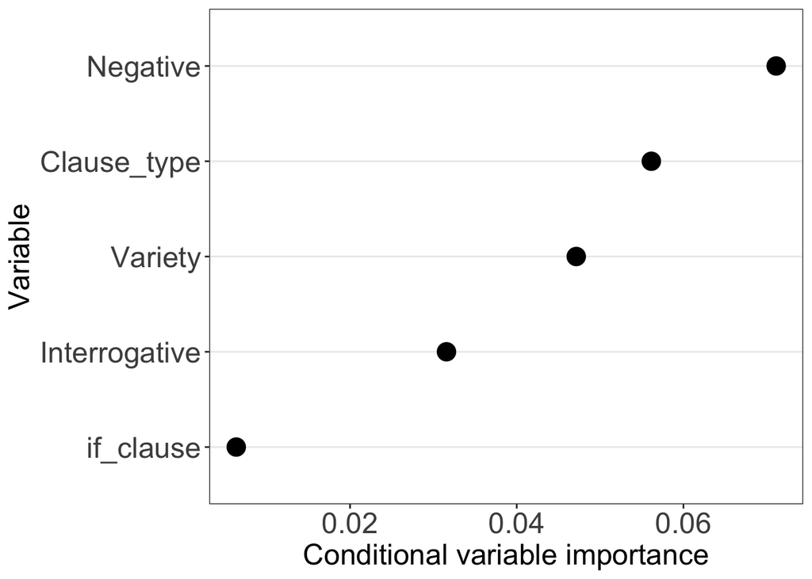

```r
(vi_plot_en <- as.data.frame(vi_en) %>% rownames_to_column() %>% ggplot(aes(y = fct_reorder(rowname, vi_en), x = vi_en)) +
  geom_point(size = 5) + xlim(min(vi_en), max(vi_en)) +
  theme_bw() +
  theme(panel.grid.major.x = element_blank()) +
  theme(panel.grid.minor = element_blank()) + xlab("Conditional variable importance") + ylab("Variable") +
  theme(axis.text = element_text(size = 18)) +
  theme(axis.title = element_text(size = 18)) +
  theme(strip.text = element_text(size = 18)) +
  theme(legend.text = element_text(size = 18)) +
  theme(legend.title = element_text(size = 18, face = "bold")) +
  theme(text = element_text(size = 18)))
```

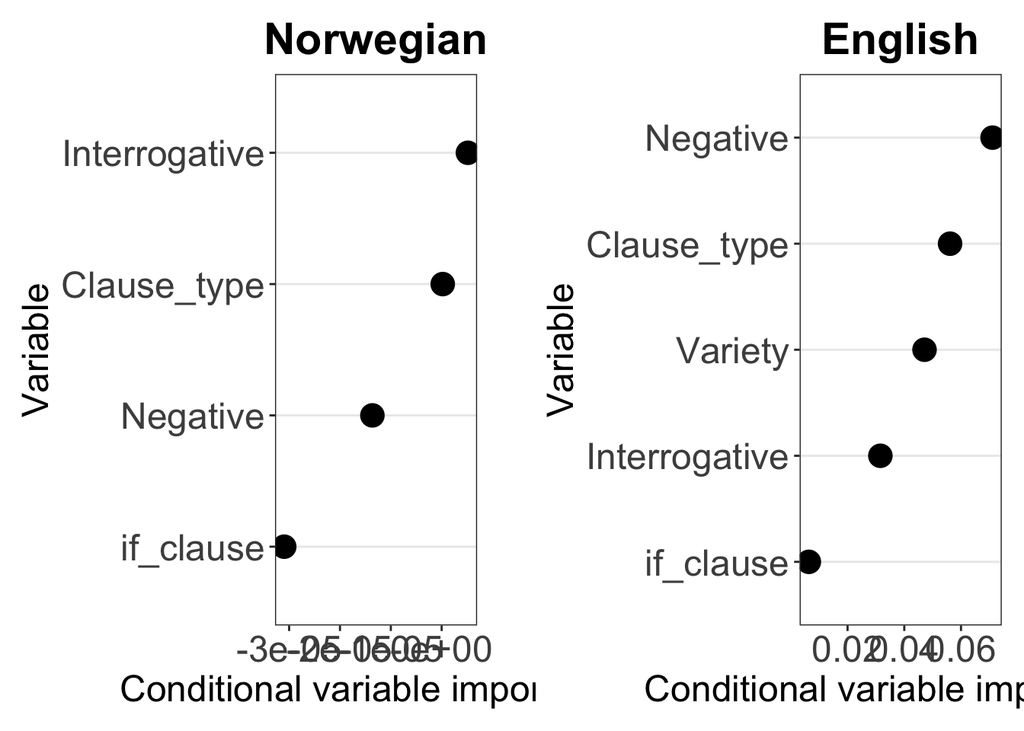

```r
# both plots
vi_plot_nor + ggtitle("Norwegian") +
  theme(plot.title = element_text(face = "bold", hjust = 0.5)) +
  plot_spacer() +
  vi_plot_en + ggtitle("English") +
  theme(plot.title = element_text(face = "bold", hjust = 0.5)) +
  plot_layout(widths = c(4,.5,4))
```

```r
# ggsave("figures/forest_NOR_EN.png", width = 12, height = 5)
```

## Check model fit

Model accuracy (number of correct predictions / number of observations)

```r
# fitted values for out of bag sample
pred.eng <- predict(for_en, OOB = T)
```

```r
table(pred.eng)
```

```
## pred.eng
##     will      'll    shall    won't going to    gonna
##        0     5873        0      473     2067      357
```

```r
table(eng$cxn1)
```

```
##
##     will      'll    shall    won't going to    gonna
##     1383     3302      133      443     2017     1492
```

```r
table(pred.eng, eng1$cxn1)
```

```
##
## pred.eng   will  'll shall won't going to gonna
##   will        0    0     0     0        0     0
##   'll       922 3086    35     0      906   924
##   shall       0    0     0     0        0     0
##   won't      11   18     1   233       42   168
##   going to  401  156    16   210     1013   271
##   gonna      49   42    81     0       56   129
```

```r
sum(as.numeric(sapply(1:length(pred.eng), function(i) pred.eng[i] == eng1$cxn1[i]))) / length(pred.eng)
```

```
## [1] 0.5086659
```

# Boruta analysis

## Norwegian

```r
# first Boruta model for Norwegian
nor$Lexeme <- factor(nor$Lexeme)
set.seed(19551105)
boruta01 <- Boruta(Cx ~ Negative+Interrogative+if_clause+Clause_type+Lexeme,
                data = nor)

# decision
getConfirmedFormula(boruta01)
```

```
## Cx ~ Lexeme + Clause_type + if_clause + Interrogative + Negative
## <environment: 0x7f7ca6ac8ce0>
```

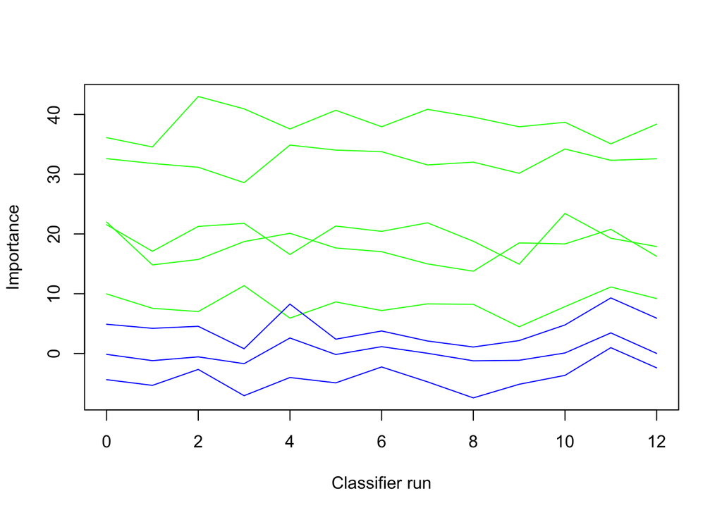

```r
plotImpHistory(boruta01)
```

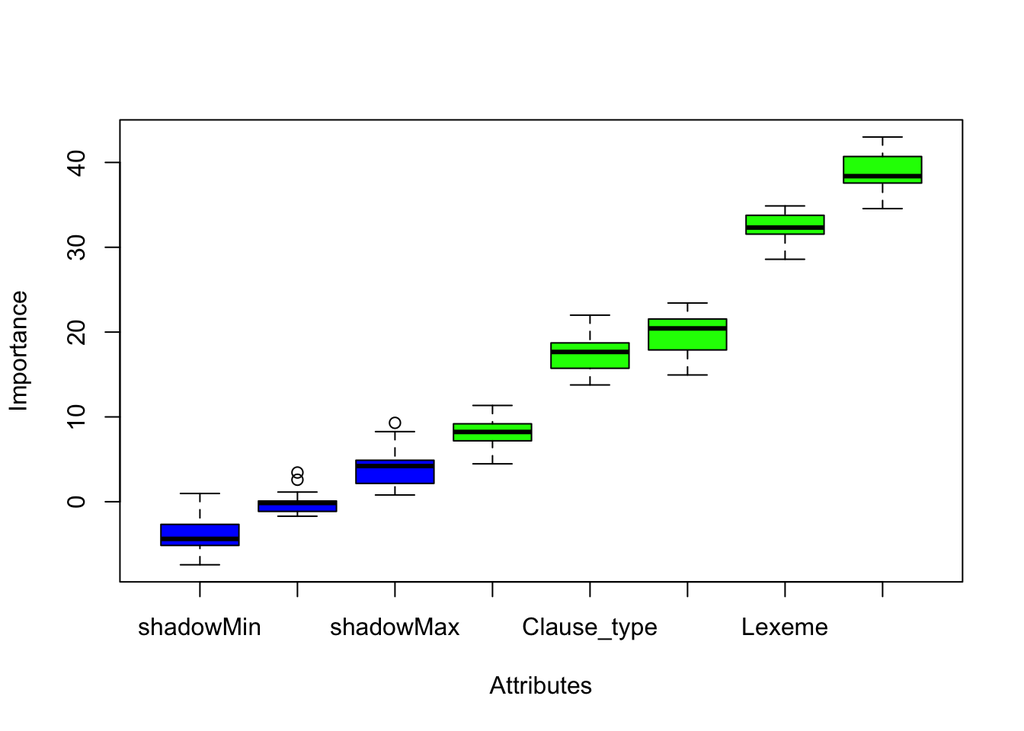

```r
plot(boruta01)
```

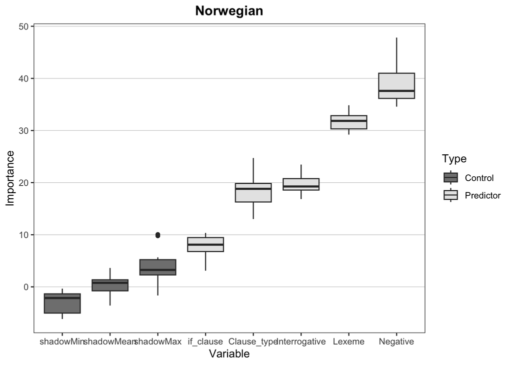

```r
# Boruta model with confirmed formula
set.seed(19551105)
boruta02 <- Boruta(Cx ~ Lexeme + Clause_type + if_clause +
                     Interrogative + Negative,
                   data = nor)


(boruta_NOR <- as.data.frame(boruta02$ImpHistory) %>% pivot_longer(cols = 1:length(as.data.frame(boruta02$ImpHistory) )) %>% setNames(c("Variable", "Importance")) %>%
  mutate(Type = ifelse(str_detect(Variable, "shadow"), "Control", "Predictor")) %>%
  mutate(Type = factor(Type),
                Variable = factor(Variable)) %>%
  ggplot(aes(x = reorder(Variable, Importance, mean), y = Importance, fill = Type)) +
  geom_boxplot() +
  theme_bw() +
  scale_fill_grey(start = .5, end = .9) +
  xlab("Variable") + ylab("Importance") + ggtitle("Norwegian") +
  theme(plot.title = element_text(face = "bold", hjust = 0.5)) +
  theme(panel.grid.major.y = element_line(linewidth = .2, color = "grey75"),
        panel.grid.major.x = element_blank(),
        panel.grid.minor = element_blank()))
```

## English

```r
# first Boruta model for English
set.seed(2015)
boruta_en01 <- Boruta(cxn ~ Negative+Interrogative+if_clause+Clause_type+Variety+Lexeme,
                data = eng1)


# decision
getConfirmedFormula(boruta_en01)
```

```
## cxn ~ Lexeme + Variety + Clause_type + if_clause + Interrogative +
##     Negative
## <environment: 0x7f7c551e9c80>
```

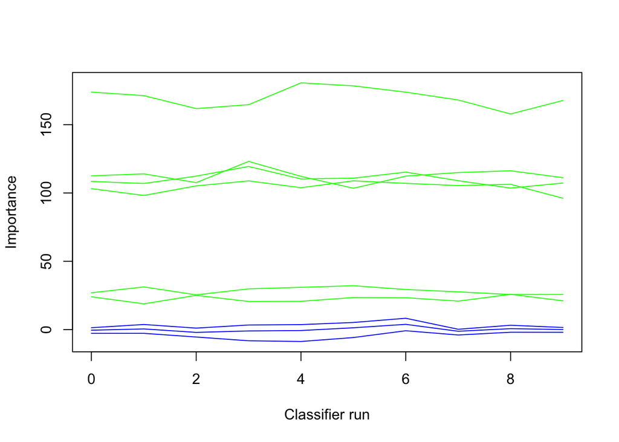

```r
plotImpHistory(boruta_en01)
```

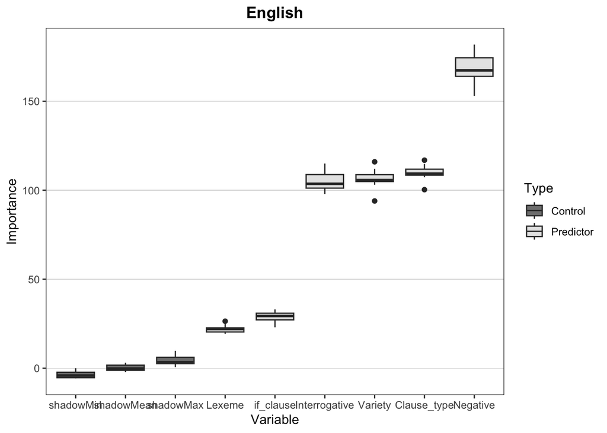

```r
# Boruta model with confirmed formula
boruta_en02 <- Boruta(cxn ~ Lexeme + Variety + Clause_type + if_clause + Interrogative + Negative,
                      data = eng1)

(boruta_EN <- as.data.frame(boruta_en02$ImpHistory) %>% pivot_longer(cols = 1:length(as.data.frame(boruta_en02$ImpHistory))) %>% setNames(c("Variable", "Importance")) %>%
  mutate(Type = ifelse(str_detect(Variable, "shadow"), "Control", "Predictor")) %>%
  mutate(Type = factor(Type),
                Variable = factor(Variable)) %>%
  ggplot(aes(x = reorder(Variable, Importance, mean), y = Importance, fill = Type)) +
  geom_boxplot() +
  theme_bw() +
  scale_fill_grey(start = .5, end = .9) +
  xlab("Variable") + ylab("Importance") + ggtitle("English") +
  theme(plot.title = element_text(face = "bold", hjust = 0.5)) +
  theme(panel.grid.major.y = element_line(linewidth = .2, color = "grey75"),
        panel.grid.major.x = element_blank(),
        panel.grid.minor = element_blank()))
```

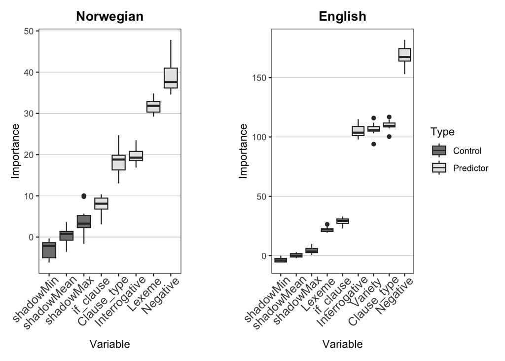

```r
# both plots
boruta_NOR +
  theme(axis.text.x = element_text(angle=45, hjust=.9, size=12)) +
  plot_spacer() + boruta_EN +
  theme(axis.text.x = element_text(angle=45, hjust=.9, size=12)) +
  plot_layout(guides = "collect", widths = c(4,1,4))
```

```r
# ggsave("figures/boruta.png", width = 15, height = 6.5)
```

# Collostructional analysis

(Multiple) distinctive collexeme analysis is used to find the lexical items that are most strongly associated with the three variants.

## Covarying-collexeme analysis: Norwegian

```r
mdca_nor <- nor %>% select(Cx, Lexeme) %>% as.data.frame %>% collex.covar()

mdca_nor %>% filter(SLOT1=="vil")
```

| SLOT1 | SLOT2 | fS1 | fS2 | OBS | EXP | ASSOC | COLL.STR.LOGL | SIGNIF |
| --- | --- | --- | --- | --- | --- | --- | --- | --- |
| vil | si | 914 | 470 | 164 | 65.3 | attr | 144.87513 | ***** |
| vil | tro | 914 | 37 | 30 | 5.1 | attr | 85.45140 | ***** |
| vil | ha | 914 | 765 | 193 | 106.2 | attr | 80.06766 | ***** |
| vil | påstå | 914 | 6 | 5 | 0.8 | attr | 14.65701 | *** |
| vil | innrømme | 914 | 3 | 3 | 0.4 | attr | 11.85407 | *** |
| vil | stokke | 914 | 3 | 3 | 0.4 | attr | 11.85407 | *** |
| vil | satse | 914 | 13 | 7 | 1.8 | attr | 11.52330 | *** |
| vil | anbefale | 914 | 5 | 4 | 0.7 | attr | 11.10300 | *** |
| vil | snuble | 914 | 5 | 4 | 0.7 | attr | 11.10300 | *** |
| vil | beholde | 914 | 2 | 2 | 0.3 | attr | 7.90083 | ** |

[output cut: 157 more lines]

```r
mdca_nor %>% filter(SLOT1=="skal")
```

| SLOT1 | SLOT2 | fS1 | fS2 | OBS | EXP | ASSOC | COLL.STR.LOGL | SIGNIF |
| --- | --- | --- | --- | --- | --- | --- | --- | --- |
| skal | ta | 5220 | 225 | 208 | 178.4 | attr | 30.34187 | ***** |
| skal | lage | 5220 | 61 | 61 | 48.4 | attr | 28.43318 | ***** |
| skal | begynne | 5220 | 87 | 82 | 69.0 | attr | 15.66238 | **** |
| skal | prøve | 5220 | 75 | 71 | 59.5 | attr | 14.41622 | *** |
| skal | prate | 5220 | 31 | 31 | 24.6 | attr | 14.41239 | *** |
| skal | skrive | 5220 | 31 | 31 | 24.6 | attr | 14.41239 | *** |
| skal | stå | 5220 | 73 | 69 | 57.9 | attr | 13.70237 | *** |
| skal | spille | 5220 | 44 | 43 | 34.9 | attr | 13.60477 | *** |
| skal | gjøre | 5220 | 335 | 288 | 265.7 | attr | 10.42228 | ** |
| skal | slutte | 5220 | 22 | 22 | 17.4 | attr | 10.22025 | ** |

[output cut: 566 more lines]

```r
mdca_nor %>% filter(SLOT1=="kommer")
```

| SLOT1 | SLOT2 | fS1 | fS2 | OBS | EXP | ASSOC | COLL.STR.LOGL | SIGNIF |
| --- | --- | --- | --- | --- | --- | --- | --- | --- |
| kommer | bli | 448 | 242 | 74 | 16.5 | attr | 132.00648 | ***** |
| kommer | merke | 448 | 5 | 5 | 0.3 | attr | 26.92522 | ***** |
| kommer | skje | 448 | 24 | 10 | 1.6 | attr | 23.28775 | ***** |
| kommer | savne | 448 | 4 | 4 | 0.3 | attr | 21.53180 | ***** |
| kommer | angre | 448 | 3 | 3 | 0.2 | attr | 16.14257 | **** |
| kommer | elske | 448 | 3 | 3 | 0.2 | attr | 16.14257 | **** |
| kommer | få | 448 | 230 | 32 | 15.7 | attr | 15.01724 | *** |
| kommer | klare | 448 | 20 | 7 | 1.4 | attr | 13.63381 | *** |
| kommer | vinne | 448 | 21 | 7 | 1.4 | attr | 12.93723 | *** |
| kommer | gråte | 448 | 2 | 2 | 0.1 | attr | 10.75754 | ** |

[output cut: 110 more lines]

## Covarying-collexeme analysis: British English

```r
mdca_bnc <- bnc %>% select(cxn1, Lemma) %>% as.data.frame() %>% collex.covar()

mdca_bnc %>% filter(SLOT1=="going to")
```

| SLOT1 | SLOT2 | fS1 | fS2 | OBS | EXP | ASSOC | COLL.STR.LOGL | SIGNIF |
| --- | --- | --- | --- | --- | --- | --- | --- | --- |
| going to | sit | 391 | 13 | 6 | 1.2 | attr | 11.99307 | *** |
| going to | write | 391 | 7 | 4 | 0.7 | attr | 10.06096 | ** |
| going to | guess | 391 | 3 | 2 | 0.3 | attr | 5.88667 | * |
| going to | eat | 391 | 23 | 6 | 2.1 | attr | 5.46419 | * |
| going to | aid | 391 | 1 | 1 | 0.1 | attr | 4.75344 | * |
| going to | arrange | 391 | 1 | 1 | 0.1 | attr | 4.75344 | * |
| going to | bite | 391 | 1 | 1 | 0.1 | attr | 4.75344 | * |
| going to | cap | 391 | 1 | 1 | 0.1 | attr | 4.75344 | * |
| going to | care | 391 | 1 | 1 | 0.1 | attr | 4.75344 | * |
| going to | chuck | 391 | 1 | 1 | 0.1 | attr | 4.75344 | * |

[output cut: 104 more lines]

```r
mdca_bnc %>% filter(SLOT1=="gonna")
```

| SLOT1 | SLOT2 | fS1 | fS2 | OBS | EXP | ASSOC | COLL.STR.LOGL | SIGNIF |
| --- | --- | --- | --- | --- | --- | --- | --- | --- |
| gonna | happen | 1051 | 44 | 25 | 11.0 | attr | 20.34037 | ***** |
| gonna | do | 1051 | 282 | 100 | 70.5 | attr | 16.46342 | **** |
| gonna | lie | 1051 | 4 | 4 | 1.0 | attr | 11.10560 | *** |
| gonna | listen | 1051 | 3 | 3 | 0.7 | attr | 8.32705 | ** |
| gonna | keep | 1051 | 28 | 14 | 7.0 | attr | 8.12670 | ** |
| gonna | win | 1051 | 5 | 4 | 1.2 | attr | 6.67480 | ** |
| gonna | make | 1051 | 59 | 23 | 14.7 | attr | 5.67766 | * |
| gonna | grow | 1051 | 2 | 2 | 0.5 | attr | 5.54994 | * |
| gonna | paint | 1051 | 2 | 2 | 0.5 | attr | 5.54994 | * |
| gonna | teach | 1051 | 2 | 2 | 0.5 | attr | 5.54994 | * |

[output cut: 183 more lines]

```r
mdca_bnc %>% filter(SLOT1=="will")
```

| SLOT1 | SLOT2 | fS1 | fS2 | OBS | EXP | ASSOC | COLL.STR.LOGL | SIGNIF |
| --- | --- | --- | --- | --- | --- | --- | --- | --- |
| will | be | 518 | 949 | 163 | 116.9 | attr | 25.05678 | ***** |
| will | choose | 518 | 2 | 2 | 0.2 | attr | 8.38395 | ** |
| will | help | 518 | 17 | 6 | 2.1 | attr | 5.98228 | * |
| will | like | 518 | 9 | 4 | 1.1 | attr | 5.72178 | * |
| will | cancel | 518 | 3 | 2 | 0.4 | attr | 4.82680 | * |
| will | guarantee | 518 | 3 | 2 | 0.4 | attr | 4.82680 | * |
| will | mean | 518 | 3 | 2 | 0.4 | attr | 4.82680 | * |
| will | apologise | 518 | 1 | 1 | 0.1 | attr | 4.19028 | * |
| will | approach | 518 | 1 | 1 | 0.1 | attr | 4.19028 | * |
| will | arrive | 518 | 1 | 1 | 0.1 | attr | 4.19028 | * |

[output cut: 131 more lines]

```r
mdca_bnc %>% filter(SLOT1=="won't")
```

| SLOT1 | SLOT2 | fS1 | fS2 | OBS | EXP | ASSOC | COLL.STR.LOGL | SIGNIF |
| --- | --- | --- | --- | --- | --- | --- | --- | --- |
| won't | know | 233 | 43 | 12 | 2.4 | attr | 22.48298 | ***** |
| won't | be | 233 | 949 | 75 | 52.6 | attr | 12.08005 | *** |
| won't | download | 233 | 2 | 2 | 0.1 | attr | 11.58918 | *** |
| won't | bother | 233 | 5 | 3 | 0.3 | attr | 10.89107 | *** |
| won't | affect | 233 | 1 | 1 | 0.1 | attr | 5.79052 | * |
| won't | beep | 233 | 1 | 1 | 0.1 | attr | 5.79052 | * |
| won't | bind | 233 | 1 | 1 | 0.1 | attr | 5.79052 | * |
| won't | budge | 233 | 1 | 1 | 0.1 | attr | 5.79052 | * |
| won't | calibrate | 233 | 1 | 1 | 0.1 | attr | 5.79052 | * |
| won't | compromise | 233 | 1 | 1 | 0.1 | attr | 5.79052 | * |

[output cut: 56 more lines]

```r
mdca_bnc %>% filter(SLOT1=="shall")
```

| SLOT1 | SLOT2 | fS1 | fS2 | OBS | EXP | ASSOC | COLL.STR.LOGL | SIGNIF |
| --- | --- | --- | --- | --- | --- | --- | --- | --- |
| shall | put | 113 | 74 | 10 | 2.0 | attr | 17.81925 | **** |
| shall | google | 113 | 1 | 1 | 0.0 | attr | 7.24240 | ** |
| shall | overrule | 113 | 1 | 1 | 0.0 | attr | 7.24240 | ** |
| shall | photocopy | 113 | 1 | 1 | 0.0 | attr | 7.24240 | ** |
| shall | repick | 113 | 1 | 1 | 0.0 | attr | 7.24240 | ** |
| shall | return | 113 | 1 | 1 | 0.0 | attr | 7.24240 | ** |
| shall | roll | 113 | 1 | 1 | 0.0 | attr | 7.24240 | ** |
| shall | stir | 113 | 1 | 1 | 0.0 | attr | 7.24240 | ** |
| shall | whistle | 113 | 1 | 1 | 0.0 | attr | 7.24240 | ** |
| shall | call | 113 | 10 | 2 | 0.3 | attr | 4.92267 | * |

[output cut: 34 more lines]

## Covarying-collexeme analysis: American English

```r
mdca_oanc <- oanc %>% select(cxn1, Lemma) %>% as.data.frame() %>% collex.covar()

mdca_oanc %>% filter(SLOT1=="going to")
```

| SLOT1 | SLOT2 | fS1 | fS2 | OBS | EXP | ASSOC | COLL.STR.LOGL | SIGNIF |
| --- | --- | --- | --- | --- | --- | --- | --- | --- |
| going to | cost | 1626 | 22 | 18 | 7.8 | attr | 19.91562 | ***** |
| going to | do | 1626 | 262 | 125 | 93.3 | attr | 17.06768 | **** |
| going to | be | 1626 | 919 | 378 | 327.4 | attr | 14.97858 | *** |
| going to | run | 1626 | 20 | 15 | 7.1 | attr | 12.93314 | *** |
| going to | lose | 1626 | 13 | 10 | 4.6 | attr | 9.26667 | ** |
| going to | beat | 1626 | 4 | 4 | 1.4 | attr | 8.26295 | ** |
| going to | happen | 1626 | 59 | 31 | 21.0 | attr | 7.11282 | ** |
| going to | try | 1626 | 39 | 22 | 13.9 | attr | 7.02803 | ** |
| going to | produce | 1626 | 3 | 3 | 1.1 | attr | 6.19602 | * |
| going to | rain | 1626 | 3 | 3 | 1.1 | attr | 6.19602 | * |

[output cut: 247 more lines]

```r
mdca_oanc %>% filter(SLOT1=="gonna")
```

| SLOT1 | SLOT2 | fS1 | fS2 | OBS | EXP | ASSOC | COLL.STR.LOGL | SIGNIF |
| --- | --- | --- | --- | --- | --- | --- | --- | --- |
| gonna | hope | 441 | 3 | 3 | 0.3 | attr | 14.03994 | *** |
| gonna | does | 441 | 2 | 2 | 0.2 | attr | 9.35585 | ** |
| gonna | has | 441 | 2 | 2 | 0.2 | attr | 9.35585 | ** |
| gonna | have | 441 | 398 | 56 | 38.5 | attr | 8.73254 | ** |
| gonna | reach | 441 | 5 | 3 | 0.5 | attr | 7.71376 | ** |
| gonna | hurt | 441 | 9 | 4 | 0.9 | attr | 7.37085 | ** |
| gonna | think | 441 | 16 | 5 | 1.5 | attr | 5.76006 | * |
| gonna | did | 441 | 3 | 2 | 0.3 | attr | 5.73915 | * |
| gonna | achieve | 441 | 1 | 1 | 0.1 | attr | 4.67587 | * |
| gonna | approve | 441 | 1 | 1 | 0.1 | attr | 4.67587 | * |

[output cut: 101 more lines]

```r
mdca_oanc %>% filter(SLOT1=="will")
```

| SLOT1 | SLOT2 | fS1 | fS2 | OBS | EXP | ASSOC | COLL.STR.LOGL | SIGNIF |
| --- | --- | --- | --- | --- | --- | --- | --- | --- |
| will | come | 865 | 89 | 32 | 16.9 | attr | 14.47434 | *** |
| will | admit | 865 | 4 | 4 | 0.8 | attr | 13.32082 | *** |
| will | continue | 865 | 10 | 7 | 1.9 | attr | 12.36600 | *** |
| will | last | 865 | 8 | 6 | 1.5 | attr | 11.83065 | *** |
| will | increase | 865 | 3 | 3 | 0.6 | attr | 9.98780 | ** |
| will | pop | 865 | 3 | 3 | 0.6 | attr | 9.98780 | ** |
| will | fit | 865 | 5 | 4 | 0.9 | attr | 8.73537 | ** |
| will | grow | 865 | 10 | 6 | 1.9 | attr | 8.20368 | ** |
| will | consider | 865 | 2 | 2 | 0.4 | attr | 6.65665 | ** |
| will | evolve | 865 | 2 | 2 | 0.4 | attr | 6.65665 | ** |

[output cut: 182 more lines]

```r
mdca_oanc %>% filter(SLOT1=="won't")
```

| SLOT1 | SLOT2 | fS1 | fS2 | OBS | EXP | ASSOC | COLL.STR.LOGL | SIGNIF |
| --- | --- | --- | --- | --- | --- | --- | --- | --- |
| won't | let | 210 | 53 | 11 | 2.4 | attr | 17.93353 | **** |
| won't | notice | 210 | 4 | 3 | 0.2 | attr | 14.10840 | *** |
| won't | bother | 210 | 5 | 3 | 0.2 | attr | 11.96989 | *** |
| won't | know | 210 | 47 | 7 | 2.2 | attr | 7.43035 | ** |
| won't | appoint | 210 | 1 | 1 | 0.0 | attr | 6.16224 | * |
| won't | develop | 210 | 1 | 1 | 0.0 | attr | 6.16224 | * |
| won't | erase | 210 | 1 | 1 | 0.0 | attr | 6.16224 | * |
| won't | firm | 210 | 1 | 1 | 0.0 | attr | 6.16224 | * |
| won't | left | 210 | 1 | 1 | 0.0 | attr | 6.16224 | * |
| won't | lift | 210 | 1 | 1 | 0.0 | attr | 6.16224 | * |

[output cut: 54 more lines]

```r
mdca_oanc %>% filter(SLOT1=="shall")
```

| SLOT1 | SLOT2 | fS1 | fS2 | OBS | EXP | ASSOC | COLL.STR.LOGL | SIGNIF |
| --- | --- | --- | --- | --- | --- | --- | --- | --- |
| shall | say | 20 | 86 | 12 | 0.4 | attr | 70.38724 | ***** |
| shall | push | 20 | 5 | 1 | 0.0 | attr | 5.94045 | * |
| shall | kill | 20 | 9 | 1 | 0.0 | attr | 4.69892 | * |
| shall | wait | 20 | 11 | 1 | 0.0 | attr | 4.29263 | * |
| shall | see | 20 | 72 | 2 | 0.3 | attr | 4.20682 | * |
| shall | tell | 20 | 72 | 1 | 0.3 | attr | 0.96888 | ns |
| shall | be | 20 | 919 | 2 | 4.0 | rep | 1.50733 | ns |

## Lemma lists

The following CWB commands give the lemma lists for SpokenBNC2014 and the spoken component of OANC:

```bash
cwb-scan-corpus spokenbnc2014 lemma > "spokenbnc2014_lemmas.tsv"
cwb-scan-corpus oancspoken lemma > "oancspoken_lemmas.tsv"
```

The lemma lists can be used to conduct simple collexeme analyses for the individual constructions.